# Exercise 10:

# Spatial analysis with raster objects

This exercise is based on a study of ecological niche modeling techniques, but applied to data of Bigfoot sightings:

Lozier, J. D., P. Aniello, and M. J. Hickerson. 2009. “Predicting the Distribution of Sasquatch in Western North America: Anything Goes with Ecological Niche Modelling.” Journal of Biogeography 36 (9): 1623–27. https://doi.org/10.1111/j.1365-2699.2009.02152.x.

It also draws on [materials](https://rspatial.org/terra/index.html) from the originators of the `terra` package. Here, we will use Bigfoot sightings and environmental data to evaluate what conditions would be conducive for finding Bigfoot.

# Load packages

First we’ll load the packages we need. Besides the usual suspects, we’ll add the `randomforest` package to help us with niche modeling.

```r
require("sf")
require("terra")
require("ggplot2")
require("randomforest")
require("RColorBrewer")
```

## Load vector data

Next, we load in the Bigfoot sightings data shapefile:

```r
bigfoot<-st_read("bigfootSightings.shp")
```

This is already subset to records from the continental United States. In addition, we have two raster datasets for average annual rain and temperature from the same area that come from the [US Forest Service](https://www.fs.fed.us/rm/boise/AWAE/projects/national-forest-climate-change-maps.html):

```r
rain<-rast("usPPT.tif")

temp<-rast("usTemp.tif")
```

We will use these as our predictive variables in our model of Bigfoot’s niche.

As usual, we can use `ggplot` to plot these datasets. Remember that to plot a `SpatRaster`, we need to convert it to an xy dataframe:

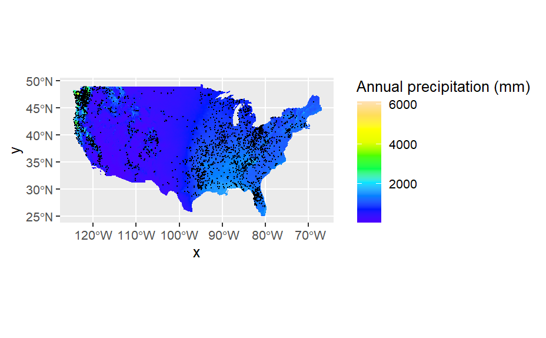

```r
rain2<-as.data.frame(rain,xy=TRUE)

 g1<-ggplot() +
   geom_raster(data=rain2,aes(x,y,fill = usPPT)) +
  geom_sf(data = bigfoot,color="black",shape=16,cex=0.1)

temp2<-as.data.frame(temp,xy=TRUE)

  g2<-ggplot() +
   geom_raster(data=temp2,aes(x,y,fill = usTemp)) +
  geom_sf(data = bigfoot,color="black",shape=16,cex=0.1)

  g1
```

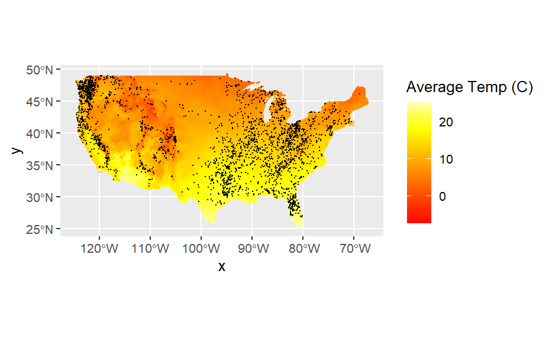

```r
  g2
```

```r
NA
```

Looks about right!

## Try it yourself!

The Bigfoot data includes a `Class` attribute indicating the quality of the sighting. Change the plot to reflect these values. # Extract values

In order to make our lives easier, we’ll want to combine our environmental rasters into a single SpatRaster object, which we can do very easily by treating them as a vector:

```r
#combine environmental rasters
envData<-c(rain,temp)
```

Also, rather than have to remember the layer names that come from the original datasets, we’ll change the names of the rasters with the `names` function:

```r
names(envData)<-c("rain","temp")
```

Now we can use `extract` to pull out values for these variables

```r
bfEnv <- extract(envData, vect(bigfoot),xy=TRUE)
head(bfEnv)
```

#Plot

```r
#envData<-data.frame(rain=bfrain$usPPT,temp=bftemp$usTemp)
g3<-ggplot()+
  geom_point(data=bfEnv,aes(x=rain,y=temp))
print(g3)
```

[output not shown]

## Get background values

In order to make predictions from raster data about what conditions we might expect Bigfoot to inhabit, we ideally want points that indicate presence *and* absence. However, the sample we have is not systematic, something that is also true for many datasets in the anthropological sciences.

Instead, we can assess the sightings data against background variability. This is similar to using CSR in point pattern studies. This will compare environments where Bigfoot has been seen to what it would be like if Bigfoots (Bigfeet?) were literally everywhere.

```r
bgEnv<-spatSample(envData,5000,"random",na.rm=TRUE, xy=TRUE)
bgEnv
```

Now we can plot both of these datasets to get sense of their differences.

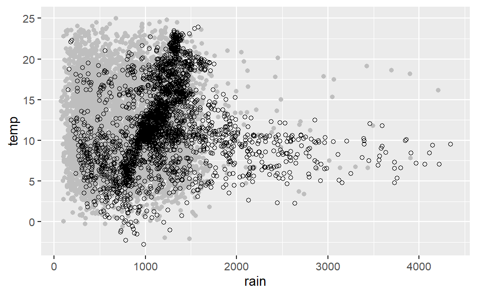

```r
bgEnvData<-data.frame(rain=bgRain$usPPT,temp=bgTemp$usTemp)
g3<-ggplot()+
  geom_point(data=bgEnvData,aes(x=rain,y=temp),col="grey")+
  geom_point(data=bfEnv,aes(x=rain,y=temp),shape=1)
print(g3)
```

There’s a fair bit of overlap, but it seems like Bigfoot generally prefers the wetter climates of the USA.

# Creating the training dataset

To create the training data for our model, we’ll subset our data to the western USA. We could model the entire country, but like many species in North America, there is likely to be distinct Bigfoot subspecies between the east and west. We’ll use 102 W as our dividing line:

```r
#western bigfoot points
bigfootWest<-subset(bfEnv,x < -102 )
```

For the model data, we need to know whether an observation is positive (1) or negative (0) as well as the associated environemental data (in this case rain and temperature). To do this we’ll want to know how many positive and negative cases we have. We can use `length` for this on the first column of each dataset:

```r
#Get number of observations in the positive and background classes
bfObs<-length(bigfootWest[,1])
bgObs<-length(bgEnv[,1])
```

Next, we’ll use `append` to create vectors for rain and temperature with the bigfoot observations first, then the background observations following:

```r
rainfall<-append(bigfootWest$rain,bgEnv$rain)
temperature<-append(bigfootWest$temp,bgEnv$temp)
```

```r
pa<-c(rep(1,bfObs),rep(0,bgObs))
```

Finally, we bring it all together into a single dataframe:

```r
bfData<-data.frame(pa,rainfall,temperature)

head(bfData)
```

Now we’re ready to start model-building!

# Using `randomforest` to build a model

[Random Forest](https://www.stat.berkeley.edu/~breiman/randomforest2001.pdf) is a machine learning algorithm based on decision trees. Decision-trees go through a sequence of yes/no questions to determine when a condition is true or false. Think about a decision about whether to go out to a restaurant. Do you have food you should eat at home? Are you able to afford it? And so on. The decision tree structure is used to find an optimal solution, but when applied to a dataset, it suffers from overfitting.

This approach is well-suited to use more than two variables, but for simplicity’s sake we’re just using rain and temperature.

## Test data

It’s good practice to break down your model into a test and training dataset for cross-validation. Here, we’ll remove 20% of the data as a test dataset:

```r
#Select a set of 20% rows from the data
i <- sample(nrow(bfData), 0.2 * nrow(bfData))
#Make that the test data
bfTest <- bfData[i,]
#Make the rest the training data
bfTrain <- bfData[-i,]
```

TWe won’t be getting into the ins and outs of cross-validation with spatial data in this exercise, but if you’re interested in learning more about this stage of model-building, you can find more at Robin Lovelace’s [Geocomputation with R](https://geocompr.robinlovelace.net/spatial-cv.html).

## Running `randomForest`

Before we get going, we need to make sure R treats our positive/negative indicator as a factor rather than a number. We can do that using `as.factor`:

```r
#Treat pa as a factor
fpa <- as.factor(bfTrain[, 'pa'])
```

Now that’s sorted, so we can run the model using `randomForest`.

```r
bfRF <- randomForest(bfTrain[, 2:ncol(bfTrain)], fpa)
bfRF
```

[output not shown]

We can look at the relative importance of our variables using the `varImpPlot` function:

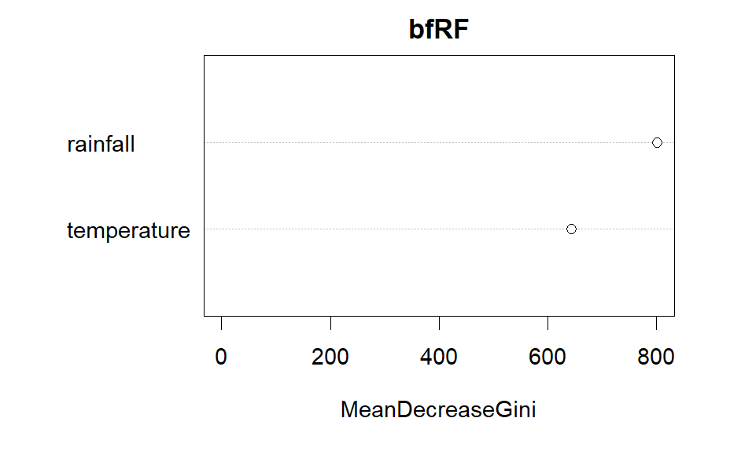

```r
varImpPlot(bfRF)
```

If we were using more parameters to build our model, then we could try and tune the random forest model using the `tuneRF` and try to get a better fit. But with two parameters this isn’t likely to buy us much of an improvement, and THE HUNT FOR BIGFOOT CANNOT WAIT A MOMENT LONGER.

# Spatial prediction

```r
names(envData)<-c("rainfall","temperature")
bigfootHabitat <- predict(envData, bfRF, na.rm=TRUE)
```

And now we can plot the result:

```r
e <- ext(xmin(bigfootHabitat), -102, ymin(bigfootHabitat), ymax(bigfootHabitat))
bigfootHabitat2<-crop(bigfootHabitat,e)
plot(bigfootHabitat2)
```

[output not shown]

At this point we could use the test data we saved to cross-validate our model; the packages `predicts` or `mlr3viz` can be used for this. This exercise demonstrates how we can use this approach to predictive modeling in an cryptoecological context, but hopefully its clear how this would be applied in other pursuits as well.

# Bringing it all together!

Here are some suggested activities for pushing your skills with this process. Since they involve modifying this code, I suggest saving the version you are working on and then copying it to a new R Notebook to do these tasks. *OK, I know you’re curious: where would Bigfoot be on the east coast? Can you modify the code above to eastern half of the country and run it again?* In your workspace there is also an elevation dataset. Can you modify the code above to include this in your analysis?